# Basic Exploratory Analysis

TARUN

26/08/2020

## R Markdown

The goal of this project is just to display that you’ve gotten used to working with the data and that you are on track to create your prediction algorithm. Please submit a report on R Pubs (http://rpubs.com/) that explains your exploratory analysis and your goals for the eventual app and algorithm. This document should be concise and explain only the major features of the data you have identified and briefly summarize your plans for creating the prediction algorithm and Shiny app in a way that would be understandable to a non-data scientist manager. You should make use of tables and plots to illustrate important summaries of the data set. The motivation for this project is to: 1. Demonstrate that you’ve downloaded the data and have successfully loaded it in.2. Create a basic report of summary statistics about the data sets.3. Report any interesting findings that you amassed so far.4. Get feedback on your plans for creating a prediction algorithm and Shiny app.

```r
library(ggplot2)
library(dplyr)
library(tokenizers)
library(stringi)
library(stringr)
library(tm)
library(quanteda)
```

## Downloading Data

```r
if(!file.exists("./Coursera-SwiftKey")){
  dir.create("./data")
  url <- "https://d396qusza40orc.cloudfront.net/dsscapstone/dataset/Coursera-SwiftKey.zip"
  download.file(Url, destfile="./data/Coursera-SwiftKey.zip", mode = "wb")
  unzip(zipfile="./data/Coursera-SwiftKey.zip", exdir="./data")
}
```

##Reading Data

```r
datablog <- readLines("./Coursera-SwiftKey/final/en_US/en_US.blogs.txt")
datanews <- readLines("./Coursera-SwiftKey/final/en_US/en_US.news.txt")
datatwitter <- readLines("./Coursera-SwiftKey/final/en_US/en_US.twitter.txt")

##summary of data
stri_stats_general(datablog)
```

```
##       Lines LinesNEmpty       Chars CharsNWhite
##      899288      899288   208361438   171926076
```

```r
stri_stats_general(datanews)
```

```
##       Lines LinesNEmpty       Chars CharsNWhite
##       77259       77259    15683765    13117038
```

```r
stri_stats_general(datatwitter)
```

```
##       Lines LinesNEmpty       Chars CharsNWhite
##     2360148     2360148   162384825   134370864
```

##Creating Data

```r
subblog <- sample(datablog,size = 1000)
subnews <- sample(datanews,size = 1000)
subtwitter <- sample(datatwitter,size = 1000)
sampledData <- c(subblog,subnews,subtwitter)
head(sampledData)
```

```
## [1] "The bradz is from The Hobbyhouse. On the crackle paint I also put dots of Liquid Pearls 'Petal Pink'."
## [2] "To take a chance to turn ourselves around"
## [3] "My firstborn started kindergarten yesterday and I started my fire."
## [4] "The problem with having a large space is that while cleaning I always get distracted by the fun stuff and end up making a bigger mess, instead of cleaning up the original mess....this problem keep multiplying until I can't move anymore and I end up on the dining room table. My goal is to hav…
## [5] "In my last post, I mentioned that Santa Clause had come to our house early. Mr. K and I don't really buy each other Christmas presents. We really enjoy shopping for the kiddos and since we tend to buy stuff we want throughout the year, and even at Christmas time!"
## [6] "PHILIPP P, HARVEY K, FLETCHER G, HUGHES A, JOLLY K. Sickness absence from work and influenza immunization. J Soc Occup Med 1987; 37: 128-129."
```

```r
corpora <- VCorpus(VectorSource(sampledData))
```

##Transforming Data

```r
toSpace <- content_transformer(function(x, pattern) gsub(pattern, " ", x))
corpora <- tm_map(corpora, toSpace, "/|@|//|$|:|:)|*|&|!|?|_|-|#|¦|€|â|™|ã|$")
corpora <- tm_map(corpora,content_transformer(tolower))
corpora <- tm_map(corpora,removePunctuation)
corpora <- tm_map(corpora,stemDocument)
corpora <- tm_map(corpora,stripWhitespace)
corpora <- tm_map(corpora,removeWords,stopwords("english"))
corpora <- tm_map(corpora,removeNumbers)
corpora <- tm_map(corpora,stripWhitespace)
```

##Data Exploration

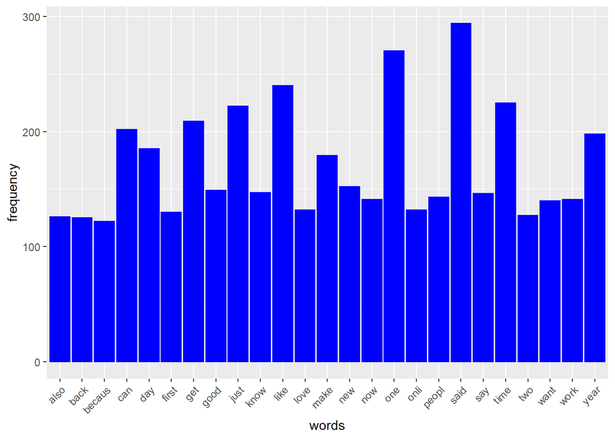

```r
dtm1 <- TermDocumentMatrix(corpora)
freq <- apply(as.matrix(dtm1),1,sum)
freq <- sort(freq,decreasing = TRUE)
freqdf <- data.frame(words = names(freq),frequency = freq)
## Plot to see distribution of words
ggplot(freqdf[1:25,],aes(words,frequency)) +
  geom_bar(stat = "identity",fill = "blue",color = "blue") +
  theme(axis.text.x = element_text(angle = 45,hjust = 1))
```

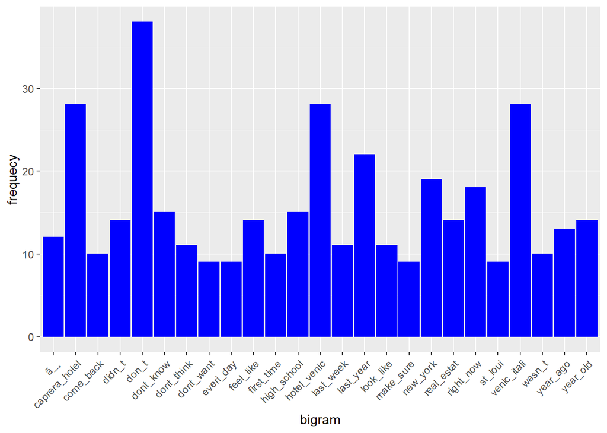

```r
## Now lets try 2 gram model
corpora <- corpus(corpora)
tk <- tokens(corpora)
tk1 <- tokens_ngrams(tk)
dfm1 <- dfm(tk1)
bifreq <- colSums(dfm1)
bifreq <- sort(bifreq,decreasing = TRUE)
bifreqdf <- data.frame(bigram = names(bifreq),frequecy = bifreq)

ggplot(bifreqdf[1:25,],aes(bigram,frequecy)) +
  geom_bar(stat = "identity",fill = "blue",color = "blue") +
  theme(axis.text.x = element_text(angle = 45,hjust = 1))
```

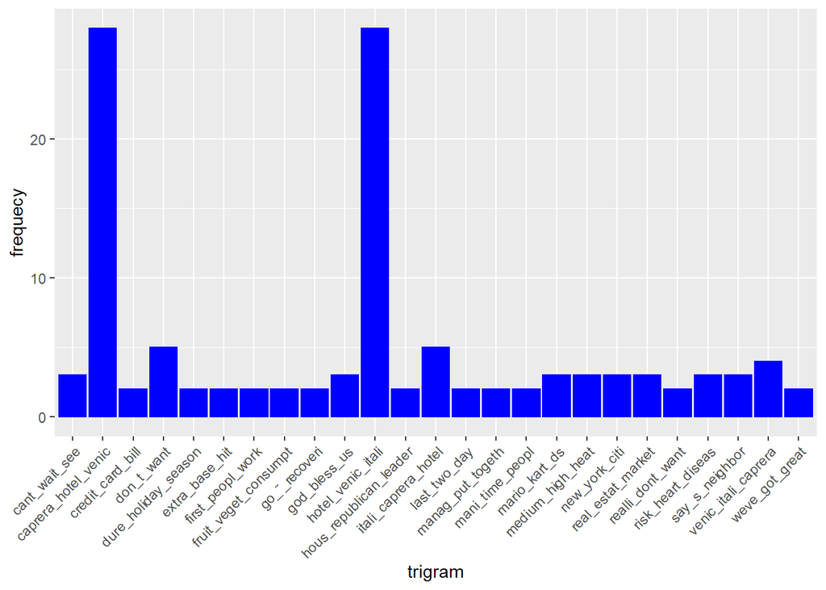

```r
## Now lets try 3 gram model
tk2 <- tokens_ngrams(tk,3)
dfm2 <- dfm(tk2)
trifreq <- colSums(dfm2)
trifreq <- sort(trifreq,decreasing = TRUE)
trifreqdf <- data.frame(trigram = names(trifreq),frequecy = trifreq)

ggplot(trifreqdf[1:25,],aes(trigram,frequecy)) +
  geom_bar(stat = "identity",fill = "blue",color = "blue") +
  theme(axis.text.x = element_text(angle = 45,hjust = 1))
```

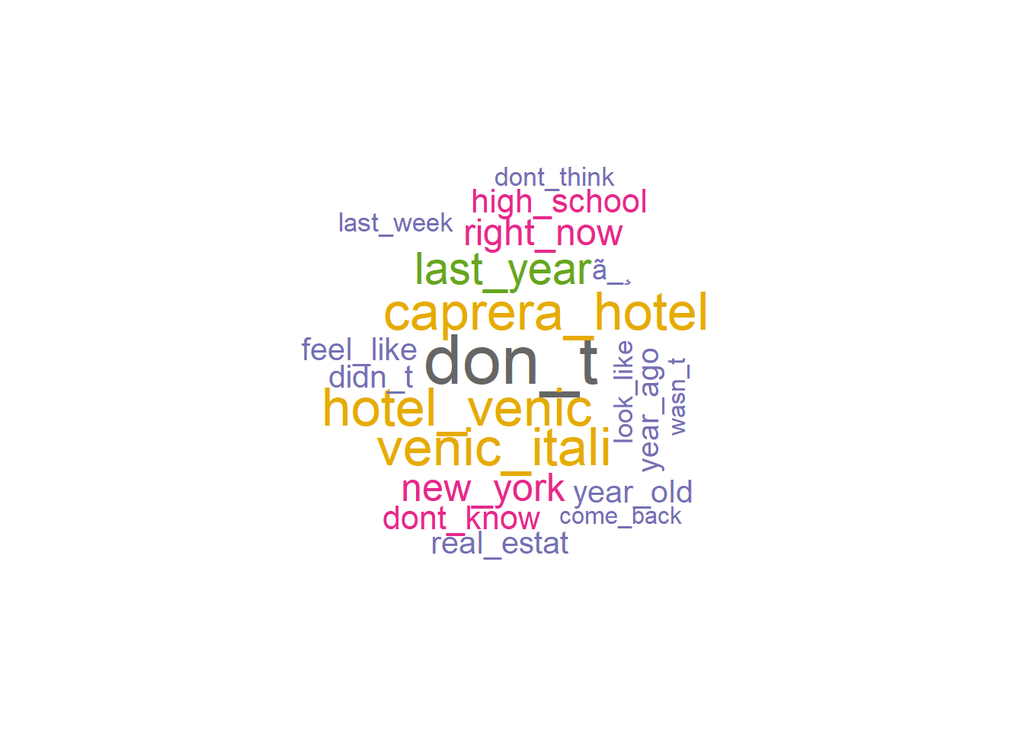

```r
## lets look at a word graph
textplot_wordcloud(dfm1,max_words = 20,color = RColorBrewer::brewer.pal(8,"Dark2"))
```

## Future plans

```r
#Planning to create a model using 2 gram and 3 gram models and coming up with a
#effective ml algorithm in a way it predicts with great accuracy.
```